# Chapter 3 - Time Series Decomposition

The data is `aus_retail`, the Box-Cox reduces a small amount of the increasing variation in the time series.

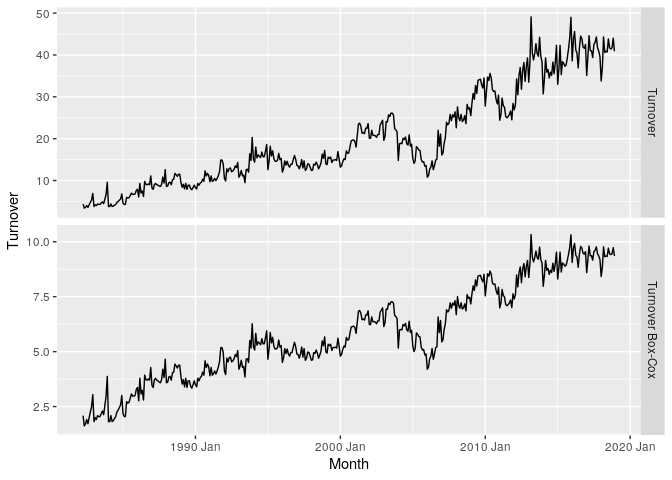

```r
retail_subset <-
  aus_retail %>%
  filter(`Series ID` == 'A3349849A')

lambda <- retail_subset %>%
  features(Turnover, features = guerrero) %>%
  pull(lambda_guerrero)

retail_subset %>%
  mutate(`Turnover Box-Cox` = box_cox(Turnover, lambda)) %>%
  pivot_longer(c(Turnover, `Turnover Box-Cox`), names_to = 'Transform', values_to = 'Turnover') %>%
  ggplot() +
  geom_line(aes(Month, Turnover)) +
  facet_grid(rows = vars(Transform), scales = 'free')
```

6. **Show that a 3×5 MA is equivalent to a 7-term weighted moving average with weights of 0.067, 0.133, 0.200, 0.200, 0.200, 0.133, and 0.067.**

With a single $5\text{-MA}$, $5 = 2k + 1$, thus $k = 2$, so our $t$ indicies go from $[-2, 2]$.

$$\hat{T}_{t(5)} = \frac{1}{5}( y_{t-2} + y_{t-1} + y_{t} + y_{t+1} + y_{t+2} )$$

If we then apply a $3\text{-MA}$ to this, our $k = 1$, with our indicies going from [-1,1]. This means we’ll have:

$$\hat{T}_t = \frac{1}{3}\big[ \\
\frac{1}{5}( y_{t-3} + y_{t-2} + y_{t-1} + y_{t} + y_{t+1} ) + \\
\frac{1}{5}( y_{t-2} + y_{t-1} + y_{t} + y_{t+1} + y_{t+2} ) + \\
\frac{1}{5}( y_{t-1} + y_{t} + y_{t+1} + y_{t+2} + y_{t+3} ) + \\
\big]$$

Summing up the indicies, there’s $1 \times y_{t-3}$, $2 \times y_{t-2}$, etc.

```r
c(
  1/3 *  1/5,
  2 * (1/3) * (1/5),
  3 * (1/3) * (1/5),
  3 * (1/3) * (1/5),
  3 * (1/3) * (1/5),
  2 * (1/3) * (1/5),
  1/3 *  1/5
)
```

```
## [1] 0.06666667 0.13333333 0.20000000 0.20000000 0.20000000 0.13333333
## [7] 0.06666667
```

This is the same as a weighted moving average with these coefficients.

7. **he fma::plastics data set consists of the monthly sales (in thousands) of product A for a plastics manufacturer for five years.**
1. **Plot the time series of sales of product A. Can you identify seasonal fluctuations and/or a trend-cycle?**

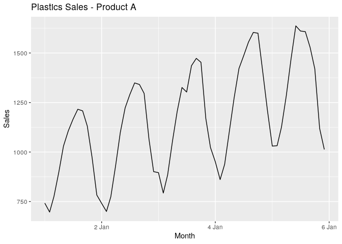

```r
prod_a_sales <-
  fma::plastics %>%
  as_tsibble() %>%
  rename(Month = index, Sales = value)

prod_a_sales %>%
  ggplot() +
  geom_line(aes(Month, Sales)) +
  labs(
    title = 'Plastics Sales - Product A'
  )
```

From this we can see a generate trend upwards (no cycles), with a yearly seasonal component.

2. **Use a classical multiplicative decomposition to calculate the trend-cycle and seasonal indices.**

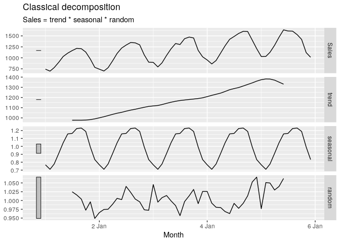

```r
prod_a_sales %>%
  model(classical_decomposition(Sales, type = 'multiplicative')) %>%
  components() %>%
  autoplot()
```

3. **Do the results upport the graphical interpretation?**

Yes the results do support it.

4. **Plot the seasonally adjusted data**

We’ll use an STL.

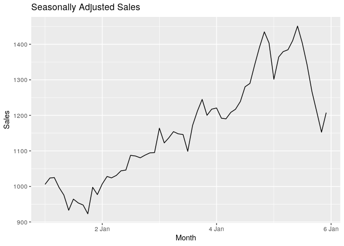

```r
prod_a_sales %>%
  model(STL(Sales)) %>%
  components() %>%
  ggplot() +
  geom_line(aes(Month, season_adjust)) +
  labs(
    y = 'Sales',
    title = 'Seasonally Adjusted Sales'
  )
```

**Change one observation to be an outlier (e.g., add 500 to one observation), and recompute the seasonally adjusted data. What is the effect of the outlier?**

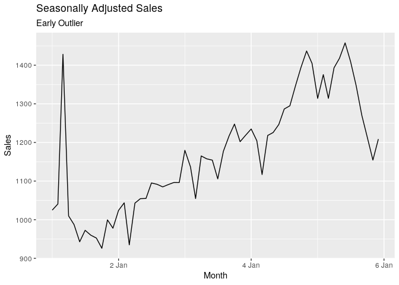

```r
prod_a_sales_outlier <- prod_a_sales
prod_a_sales_outlier[3,2] <- prod_a_sales_outlier[3,2] + 500

prod_a_sales_outlier %>%
  model(STL(Sales)) %>%
  components() %>%
  ggplot() +
  geom_line(aes(Month, season_adjust)) +
  labs(
    y = 'Sales',
    title = 'Seasonally Adjusted Sales',
    subtitle = 'Early Outlier'
  )
```

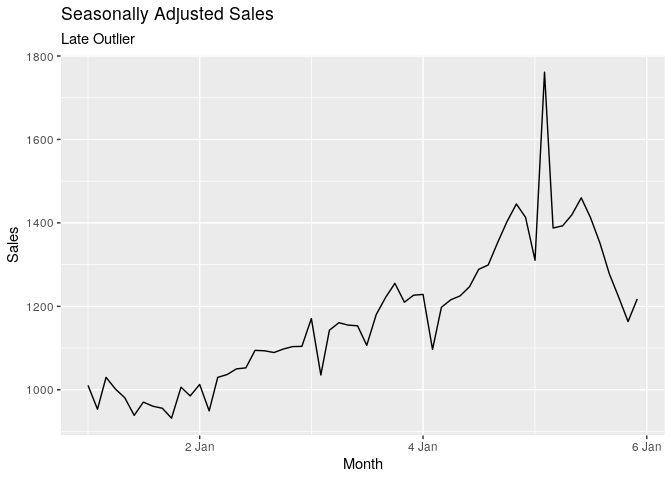

```r
prod_a_sales_outlier[3,2] <- prod_a_sales_outlier[3,2] - 500
prod_a_sales_outlier[50,2] <- prod_a_sales_outlier[50,2] + 500

prod_a_sales_outlier %>%
  model(STL(Sales)) %>%
  components() %>%
  ggplot() +
  geom_line(aes(Month, season_adjust)) +
  labs(
    y = 'Sales',
    title = 'Seasonally Adjusted Sales',
    subtitle = 'Late Outlier'
  )
```

9. **Figures 3.16 and 3.17 show the result of decomposing the number of persons in the civilian labour force in Australia each month from February 1978 to August 1995.**

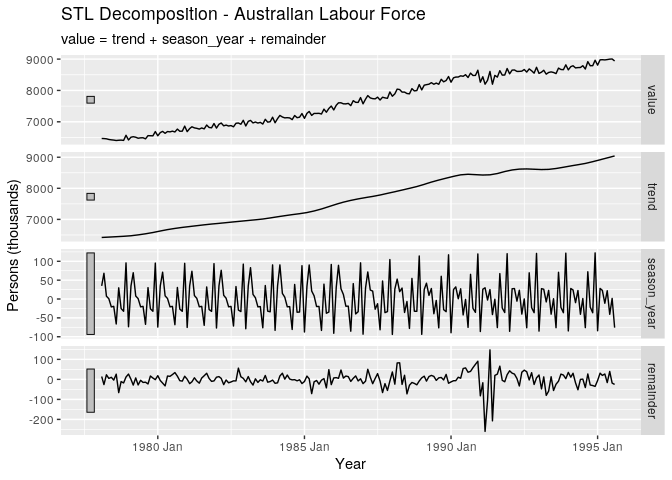

```r
aus_labour_comp <-
  labour %>%
  as_tsibble() %>%
  model(STL(value)) %>%
  components()

aus_labour_comp %>%
  autoplot() +
  labs(
    x = 'Year',
    y = 'Persons (thousands)',
    title = 'STL Decomposition - Australian Labour Force'
  )
```

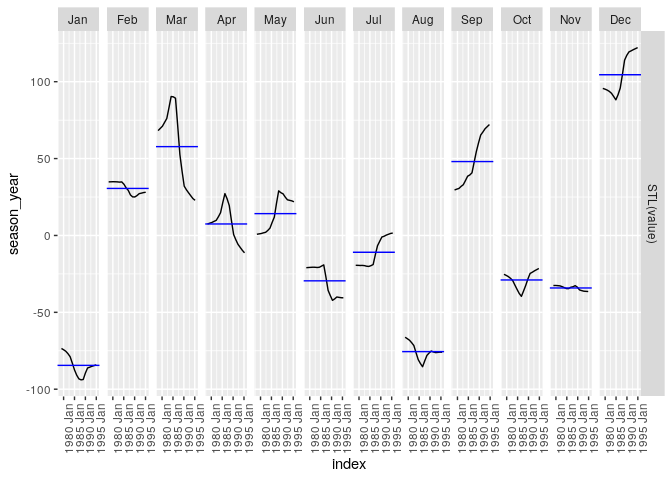

```r
aus_labour_comp %>%
  gg_subseries(season_year)
```

1. **Write about 3–5 sentences describing the results of the decomposition.**

We first take a look at the seasonal component of labour. THere is a large rise just before Christmas, with a drop off over the summar holidays. This picks back up again, slowly diminishing into Winter.

We don’t see any cycles over the long term, but we do see a flattening around 1991/1992. This lines up with the recession that ocurred then.

10. **This exercise uses the canadian_gas data (monthly Canadian gas production in billions of cubic metres, January 1960 – February 2005).**
1. **Plot the data using autoplot(), gg_subseries() and gg_season() to look at the effect of the changing seasonality over time. What do you think is causing it to change so much?**

```
## Plot variable not specified, automatically selected `.vars = Volume`
```

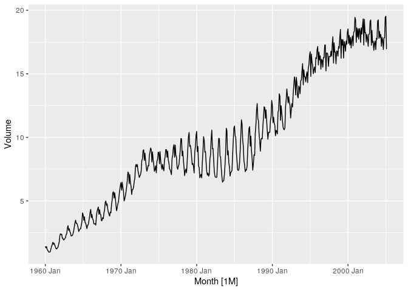

```r
canadian_gas %>%
  autoplot()
```

```r
canadian_gas %>%
  gg_subseries()
```

```
## Plot variable not specified, automatically selected `y = Volume`
```

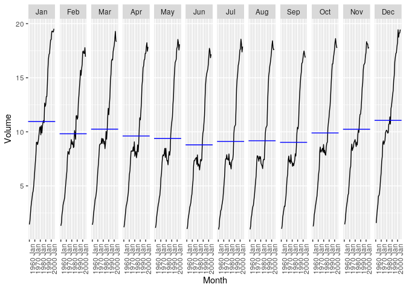

```r
canadian_gas %>%
  gg_season()
```

```
## Plot variable not specified, automatically selected `y = Volume`
```

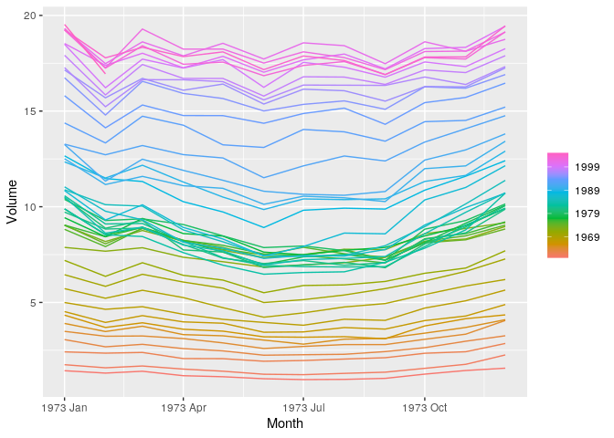

2. **Do an STL decomposition of the data. You will need to choose a seasonal window to allow for the changing shape of the seasonal component.**

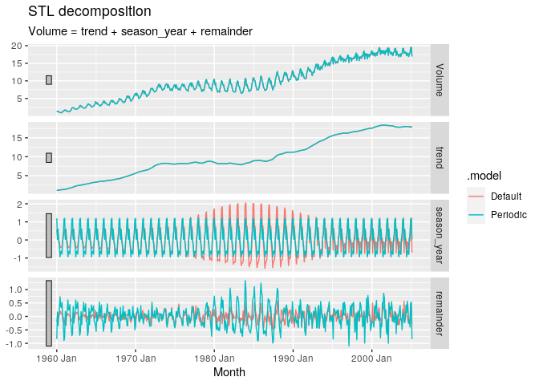

```r
canadian_gas %>%
  model(
    Periodic = STL(Volume ~ season(window = 'periodic')),
    Default = STL(Volume)
  ) %>%
  components() %>%
  autoplot()
```

3. **How does the seasonal shape change over time? [Hint: Try plotting the seasonal component using gg_seas).]**

4. **Can you produce a plausible seasonally adjusted series?**

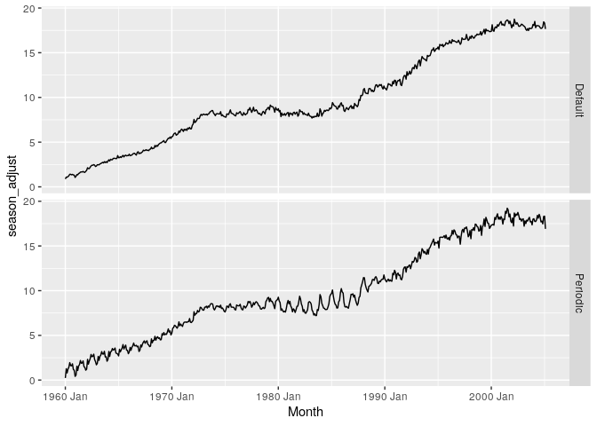

```r
canadian_gas %>%
  model(
    Periodic = STL(Volume ~ season(window = 'periodic')),
    Default = STL(Volume)
  ) %>%
  components() %>%
  ggplot() +
  geom_line(aes(Month, season_adjust)) +
  facet_grid(rows = vars(.model))
```

The change in variability of the season in the 1980s will makes it difficult to produce a seasonally adjusted series.